# Class10

Kimberly

2/6/2020

# Unsupervised Learning Mini Project

- https://bioboot.github.io/bimm143_W20/class-material/lab-9-bimm143.html

```r
fna.data <- read.csv("WisconsinCancer.csv")
wisc.df <- data.frame(fna.data)

wisc.df
```

```
##            id diagnosis radius_mean texture_mean perimeter_mean area_mean
## 1      842302         M      17.990        10.38         122.80    1001.0
## 2      842517         M      20.570        17.77         132.90    1326.0
## 3    84300903         M      19.690        21.25         130.00    1203.0
## 4    84348301         M      11.420        20.38          77.58     386.1
## 5    84358402         M      20.290        14.34         135.10    1297.0
## 6      843786         M      12.450        15.70          82.57     477.1
## 7      844359         M      18.250        19.98         119.60    1040.0
## 8    84458202         M      13.710        20.83          90.20     577.9
## 9      844981         M      13.000        21.82          87.50     519.8
## 10   84501001         M      12.460        24.04          83.97     475.9
## 11     845636         M      16.020        23.24         102.70     797.8
## 12   84610002         M      15.780        17.89         103.60     781.0
## 13     846226         M      19.170        24.80         132.40    1123.0
## 14     846381         M      15.850        23.95         103.70     782.7
```

[output cut: 3975 more lines]

Notice: Last column “X” has a bunch of NA’s. - There was probably some mistake from the Excel file, so we should clean it up to work with what we want to work with. - (i.e., no “X” (col 33), no “ID” (col 1), no “Diagnosis” (col 2)).

```r
# Convert the features of the data: wisc.data
wisc.data <- as.matrix(wisc.df[, 3:32])
# Can use head(wisc.data) to check beginning and ends of dataset to check if you are doing it correctly

# Set the row names of wisc.data
row.names(wisc.data) <- wisc.df$id
```

*Q1. How many patients are in this dataset?*

```r
nrow(wisc.data)
```

```
## [1] 569
```

*Q2. How many M’s (cancer) and how many B’s (non-cancer) are in that “diagnosis” column?*

```r
table(wisc.df[,2])
```

```
##
##   B   M
## 357 212
```

```r
# OR table(wisc.df$diagnosis)
```

*Q3. How many variables/features in the data are suffixed with "_mean"?*

```r
# looking at all the column names within wisc.data
# you could probably use this to eyeball it but would be tedious for big datasets
colnames(wisc.data)
```

```
##  [1] "radius_mean"             "texture_mean"
##  [3] "perimeter_mean"          "area_mean"
##  [5] "smoothness_mean"         "compactness_mean"
##  [7] "concavity_mean"          "concave.points_mean"
##  [9] "symmetry_mean"           "fractal_dimension_mean"
## [11] "radius_se"               "texture_se"
## [13] "perimeter_se"            "area_se"
## [15] "smoothness_se"           "compactness_se"
## [17] "concavity_se"            "concave.points_se"
## [19] "symmetry_se"             "fractal_dimension_se"
## [21] "radius_worst"            "texture_worst"
## [23] "perimeter_worst"         "area_worst"
## [25] "smoothness_worst"        "compactness_worst"
## [27] "concavity_worst"         "concave.points_worst"
## [29] "symmetry_worst"          "fractal_dimension_worst"
```

```r
# finds a patten that you give it within the input vector given
grep("_mean", colnames(wisc.data))
```

```
##  [1]  1  2  3  4  5  6  7  8  9 10
```

```r
# value = T tells you WHAT the matches are
# value = F tells you WHERE the matches are
grep("_mean", colnames(wisc.data), value = T)
```

```
##  [1] "radius_mean"            "texture_mean"           "perimeter_mean"
##  [4] "area_mean"              "smoothness_mean"        "compactness_mean"
##  [7] "concavity_mean"         "concave.points_mean"    "symmetry_mean"
## [10] "fractal_dimension_mean"
```

```r
# look at the length of counts with "_mean"
length(grep("_mean", colnames(wisc.data), value = T))
```

```
## [1] 10
```

# Principal Component Analysis

- Before we do PCA, we should check if we need to re-scale our data.
- Recall 2 common reasons for scaling data include:
1. The input variables use different units of measurement.
- The input variables have significantly different variances.
- Check the mean and standard deviation of the features (i.e. columns) of the wisc.data to determine if the data should be scaled.

Use the `colMeans()` and `apply()` functions like you’ve done before.

```r
# Check column means and standard deviations
colMeans(wisc.data)
```

```
##             radius_mean            texture_mean          perimeter_mean
##            1.412729e+01            1.928965e+01            9.196903e+01
##               area_mean         smoothness_mean        compactness_mean
##            6.548891e+02            9.636028e-02            1.043410e-01
##          concavity_mean     concave.points_mean           symmetry_mean
##            8.879932e-02            4.891915e-02            1.811619e-01
##  fractal_dimension_mean               radius_se              texture_se
##            6.279761e-02            4.051721e-01            1.216853e+00
##            perimeter_se                 area_se           smoothness_se
##            2.866059e+00            4.033708e+01            7.040979e-03
##          compactness_se            concavity_se       concave.points_se
##            2.547814e-02            3.189372e-02            1.179614e-02
##             symmetry_se    fractal_dimension_se            radius_worst
##            2.054230e-02            3.794904e-03            1.626919e+01
##           texture_worst         perimeter_worst              area_worst
##            2.567722e+01            1.072612e+02            8.805831e+02
##        smoothness_worst       compactness_worst         concavity_worst
##            1.323686e-01            2.542650e-01            2.721885e-01
##    concave.points_worst          symmetry_worst fractal_dimension_worst
##            1.146062e-01            2.900756e-01            8.394582e-02
```

```r
# 2 is the columns, 1 is for rows
# sd is the standard deviation function
# gives output in scientific notation if numbers are large/tiny
apply(wisc.data,2,sd)
```

```
##             radius_mean            texture_mean          perimeter_mean
##            3.524049e+00            4.301036e+00            2.429898e+01
##               area_mean         smoothness_mean        compactness_mean
##            3.519141e+02            1.406413e-02            5.281276e-02
##          concavity_mean     concave.points_mean           symmetry_mean
##            7.971981e-02            3.880284e-02            2.741428e-02
##  fractal_dimension_mean               radius_se              texture_se
##            7.060363e-03            2.773127e-01            5.516484e-01
##            perimeter_se                 area_se           smoothness_se
##            2.021855e+00            4.549101e+01            3.002518e-03
##          compactness_se            concavity_se       concave.points_se
##            1.790818e-02            3.018606e-02            6.170285e-03
##             symmetry_se    fractal_dimension_se            radius_worst
##            8.266372e-03            2.646071e-03            4.833242e+00
##           texture_worst         perimeter_worst              area_worst
##            6.146258e+00            3.360254e+01            5.693570e+02
##        smoothness_worst       compactness_worst         concavity_worst
##            2.283243e-02            1.573365e-01            2.086243e-01
##    concave.points_worst          symmetry_worst fractal_dimension_worst
##            6.573234e-02            6.186747e-02            1.806127e-02
```

```r
# rounds the values to 2 decimal points
round(apply(wisc.data,2,sd), 2)
```

```
##             radius_mean            texture_mean          perimeter_mean
##                    3.52                    4.30                   24.30
##               area_mean         smoothness_mean        compactness_mean
##                  351.91                    0.01                    0.05
##          concavity_mean     concave.points_mean           symmetry_mean
##                    0.08                    0.04                    0.03
##  fractal_dimension_mean               radius_se              texture_se
##                    0.01                    0.28                    0.55
##            perimeter_se                 area_se           smoothness_se
##                    2.02                   45.49                    0.00
##          compactness_se            concavity_se       concave.points_se
##                    0.02                    0.03                    0.01
##             symmetry_se    fractal_dimension_se            radius_worst
##                    0.01                    0.00                    4.83
##           texture_worst         perimeter_worst              area_worst
##                    6.15                   33.60                  569.36
##        smoothness_worst       compactness_worst         concavity_worst
##                    0.02                    0.16                    0.21
##    concave.points_worst          symmetry_worst fractal_dimension_worst
##                    0.07                    0.06                    0.02
```

**Numbers are all over the place, so it looks like we need to set scale = TRUE.**

```r
wisc.pr <- prcomp(wisc.data, scale = TRUE)
summary(wisc.pr)
```

```
## Importance of components:
##                           PC1    PC2     PC3     PC4     PC5     PC6     PC7
## Standard deviation     3.6444 2.3857 1.67867 1.40735 1.28403 1.09880 0.82172
## Proportion of Variance 0.4427 0.1897 0.09393 0.06602 0.05496 0.04025 0.02251
## Cumulative Proportion  0.4427 0.6324 0.72636 0.79239 0.84734 0.88759 0.91010
##                            PC8    PC9    PC10   PC11    PC12    PC13    PC14
## Standard deviation     0.69037 0.6457 0.59219 0.5421 0.51104 0.49128 0.39624
## Proportion of Variance 0.01589 0.0139 0.01169 0.0098 0.00871 0.00805 0.00523
## Cumulative Proportion  0.92598 0.9399 0.95157 0.9614 0.97007 0.97812 0.98335
##                           PC15    PC16    PC17    PC18    PC19    PC20   PC21
## Standard deviation     0.30681 0.28260 0.24372 0.22939 0.22244 0.17652 0.1731
## Proportion of Variance 0.00314 0.00266 0.00198 0.00175 0.00165 0.00104 0.0010
## Cumulative Proportion  0.98649 0.98915 0.99113 0.99288 0.99453 0.99557 0.9966
##                           PC22    PC23   PC24    PC25    PC26    PC27    PC28
## Standard deviation     0.16565 0.15602 0.1344 0.12442 0.09043 0.08307 0.03987
## Proportion of Variance 0.00091 0.00081 0.0006 0.00052 0.00027 0.00023 0.00005
## Cumulative Proportion  0.99749 0.99830 0.9989 0.99942 0.99969 0.99992 0.99997
##                           PC29    PC30
## Standard deviation     0.02736 0.01153
## Proportion of Variance 0.00002 0.00000
## Cumulative Proportion  1.00000 1.00000
```

*Q4: From your results, what proportion of the original variance is captured by the first principal components (PC1)?* **A4: “PC1 captures 44.27% of original variance within the whole dataset.”**

“PC1 AND PC2 capture 63% of variance (”Cumulative Prop“) within the whole dataset.” *Q5. How many principal components (PCs) are required to describe at least 70% of the original variance in the data?* **A5. 72.6% in the first 3 PCs.**

## Interpret PCA results

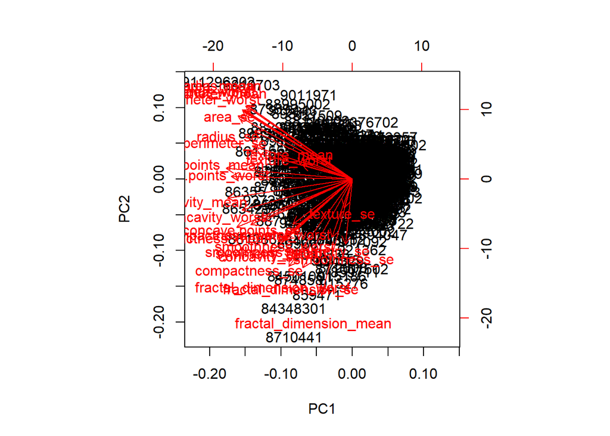

```r
# A MESS. TOO MANY VARIABLES LAYERING ON TOP OF EACH OTHER
biplot(wisc.pr)
```

```r
# We need to do our own PC1 vs. PC2 plot and color by the diagnosis
attributes(wisc.pr)
```

```
## $names
## [1] "sdev"     "rotation" "center"   "scale"    "x"
##
## $class
## [1] "prcomp"
```

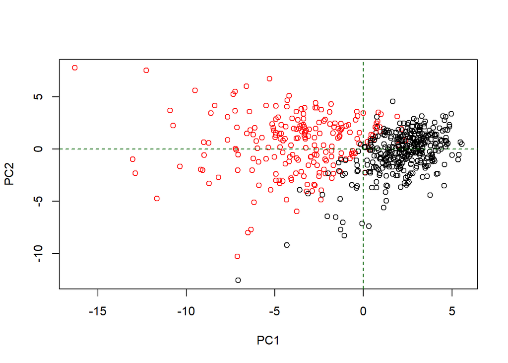

```r
plot(wisc.pr$x[,1], wisc.pr$x[,2],
     col = wisc.df$diagnosis,
     xlab = "PC1", ylab = "PC2")
abline(h = 0, col = "darkgreen", lty = 2)
abline(v = 0, col = "darkgreen", lty = 2)
```

- The benign black cells are relatively similar and grouped together neatly. - The malignant red cells are more spread out, implying that there are many ways to be cancerous.

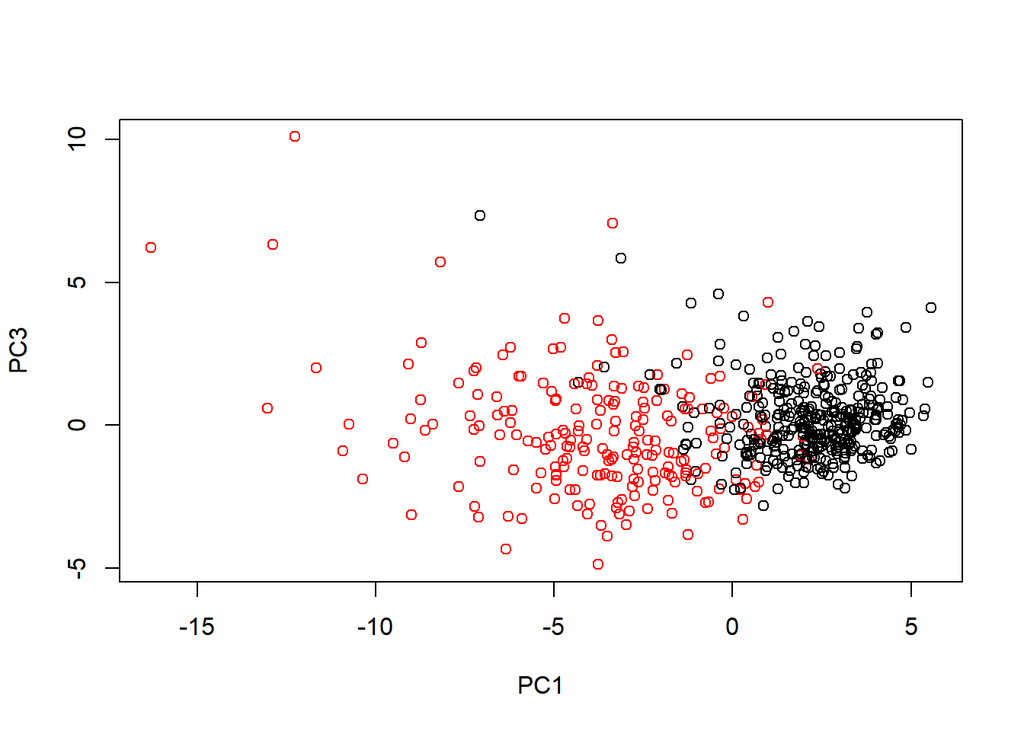

```r
plot(wisc.pr$x[,1], wisc.pr$x[,3],
     col = wisc.df$diagnosis,
     xlab = "PC1", ylab = "PC3")
```

## Cluser in PC spaces

First, let’s see if we can cluster the original data.

### Hierarchical clustering of case data

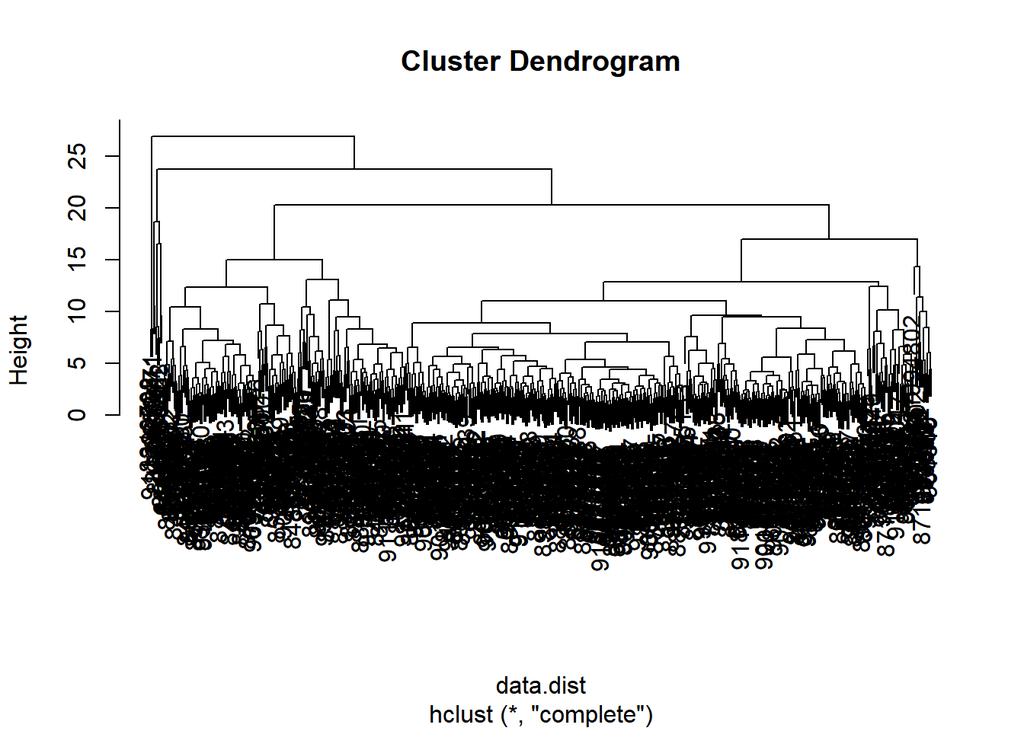

```r
# scale the data b/c it is a mess otherwise
data.scaled <- scale(wisc.data)

# calculate the Euclidean distances
data.dist <- dist(data.scaled)

# create the hcluster
wisc.hclust <- hclust(data.dist)

plot(wisc.hclust)
```

#### Combining methods

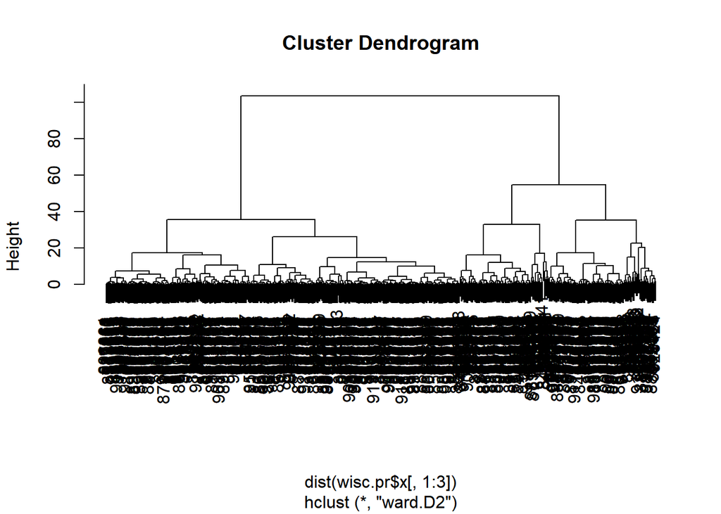

```r
# Using the minimum number of principal components required to describe at least 90% of the variability in the data, create a hierarchical clustering model with the linkage method="ward.D2".
# We use Ward’s criterion here because it is based on multidimensional variance like principal components analysis.
wisc.pr.hclust <- hclust(dist(wisc.pr$x[, 1:3]), method = "ward.D2")

plot(wisc.pr.hclust)
```

```r
grps_of_3 <- cutree(wisc.pr.hclust, k = 3)
table(grps_of_3)
```

```
## grps_of_3
##   1   2   3
## 111  92 366
```

“There are 111 in group 1, 92 in group 2, 366 in group 3.”

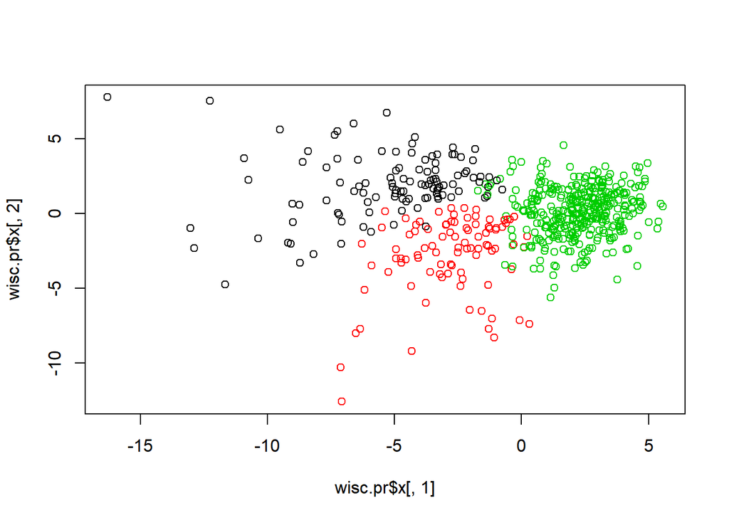

```r
plot(wisc.pr$x[,1], wisc.pr$x[,2], col=grps_of_3)
```

We can use `table()` to compare `$diagnosis` vector with our cluster results vector.

```r
table(grps_of_3, wisc.df$diagnosis)
```

```
##
## grps_of_3   B   M
##         1   0 111
##         2  24  68
##         3 333  33
```

“In cluster 1, there are 0 benign and 111 malignant.” “In cluster 2, there are 24 benign and 68 malignant.” “In cluster 3, there are 333 benign and 33 malignant.” - implying that cluster 3 is mainly benign. 333 true positives. (BUT there are 33 false positives. #misclassification) # sensitivity vs. specificity # dependent on the system

## Predictions w/ `predict()`

```r
new <- read.csv("new_samples.csv")
npc <- predict(wisc.pr, newdata=new)
npc
```

```
##            PC1       PC2        PC3        PC4       PC5        PC6        PC7
## [1,]  2.576616 -3.135913  1.3990492 -0.7631950  2.781648 -0.8150185 -0.3959098
## [2,] -4.754928 -3.009033 -0.1660946 -0.6052952 -1.140698 -1.2189945  0.8193031
##             PC8       PC9       PC10      PC11      PC12      PC13     PC14
## [1,] -0.2307350 0.1029569 -0.9272861 0.3411457  0.375921 0.1610764 1.187882
## [2,] -0.3307423 0.5281896 -0.4855301 0.7173233 -1.185917 0.5893856 0.303029
##           PC15       PC16        PC17        PC18        PC19       PC20
## [1,] 0.3216974 -0.1743616 -0.07875393 -0.11207028 -0.08802955 -0.2495216
## [2,] 0.1299153  0.1448061 -0.40509706  0.06565549  0.25591230 -0.4289500
##            PC21       PC22       PC23       PC24        PC25         PC26
## [1,]  0.1228233 0.09358453 0.08347651  0.1223396  0.02124121  0.078884581
## [2,] -0.1224776 0.01732146 0.06316631 -0.2338618 -0.20755948 -0.009833238
##              PC27        PC28         PC29         PC30
## [1,]  0.220199544 -0.02946023 -0.015620933  0.005269029
## [2,] -0.001134152  0.09638361  0.002795349 -0.019015820
```

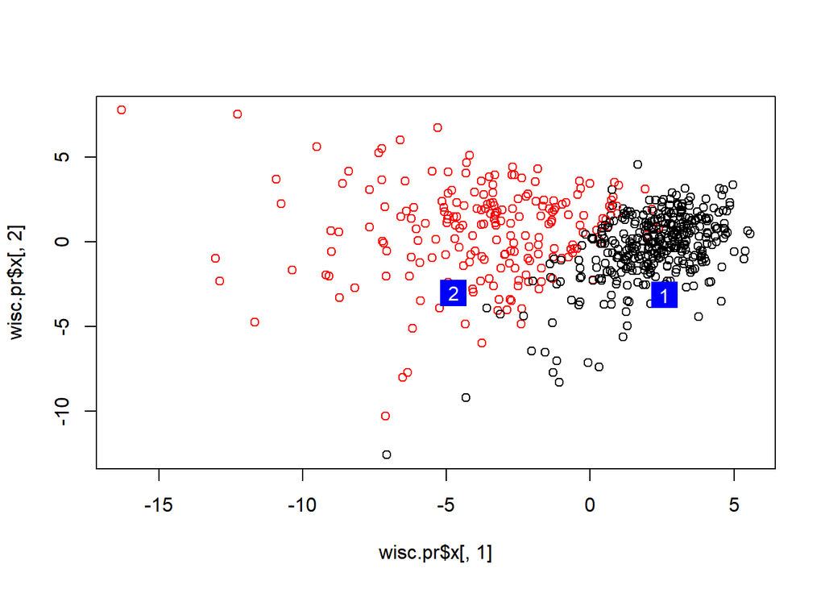

```r
plot(wisc.pr$x[,1], wisc.pr$x[,2],
     col = wisc.df$diagnosis)
points(npc[, 1], npc[, 2], col = "blue", pch = 15, cex = 3)
text(npc[,1], npc[,2], labels = c(1,2), col = "white")
```

You should be checking on patient 2 because they seem to land on the malignant area.